# probando-con-r

## Probando con R

R es un entorno y lenguaje de programación con un enfoque al análisis estadístico, utilizado ampliamente en periodismo y visualización de datos. R es diferente a otros lenguajes de programación que por lo general están diseñados para realizar muchas tareas diferentes, porque fue creado con el único propósito de hacer estadística.

### Instalar librerías

Las librerías son una herramienta útil, que permiter aumentar las funcionalidades de R. Para instalar librerías debemos usar el siguiente código:

```
install.packages("ggplot2")
```

Utilizamos el paquete ggplot2, un sistema para crear gráficos de forma declarativa, basado en la gramática de los gráficos. Se le proporciona los datos, se le dice cómo asignar las variables a la estética, qué primitivas gráficas utilizar y ggplot2 se encarga de llevarlo a cabo

### Importar librerías

Una vez que hayas instalado un paquete, hay que cargarlo para poder usas sus funciones o información

```r
library(ggplot2)
```

### Crear datos

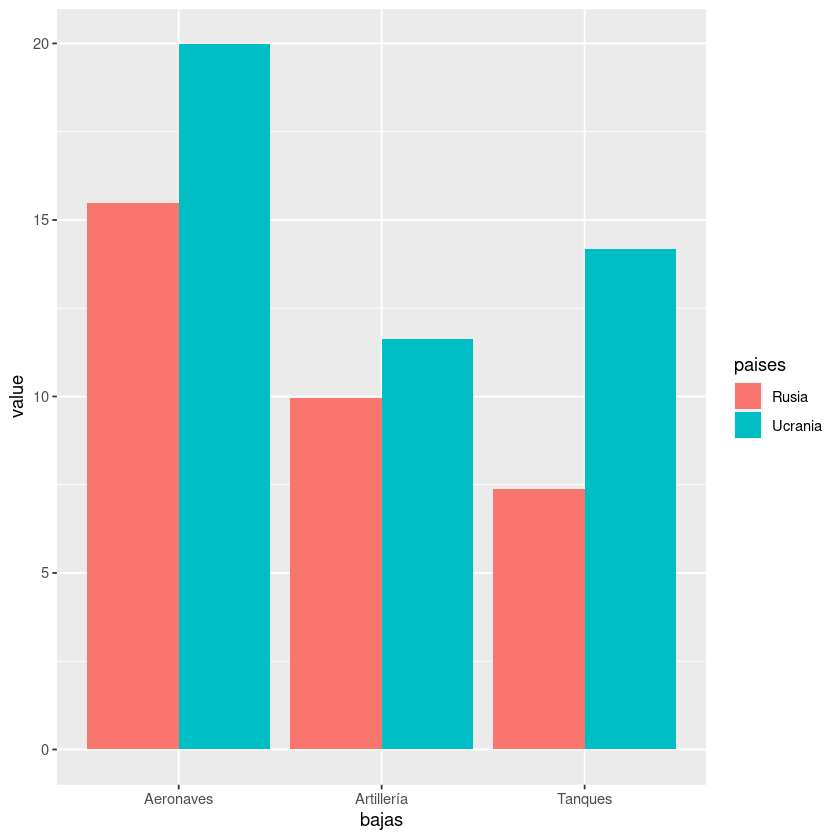

```r
# create a dataset
bajas <- c(rep("Tanques" , 2) , rep("Artillería" , 2) , rep("Aeronaves" , 2))
paises <- rep(c("Rusia" , "Ucrania") , 3)
value <- abs(rnorm(12 , 0 , 15))
data <- data.frame(bajas,paises,value)

# Grouped
ggplot(data, aes(fill=paises, y=value, x=bajas)) +
    geom_bar(position="dodge", stat="identity")
```